# Homework 4

## Problem 1. A Data Scientist Referees Ping Pong (8pts total)

The game is Ping Pong. Players grab their paddles and hit the ping pong ball back and forth scoring points one at a time. The game continues until one player reaches 21 points, and at that point the game ends unless the point difference is less than 2. If it is less than 2 the game continues until one player wins by 2.

Suppose Athena and Bacchus play and Bacchus wins 21 to 15. Bacchus is super excited but Athena says that they should have a rematch, because she’s sure that Bacchus is not better than her, it was just a fluke.

Time for a Data Scientist to settle this dispute. We must consider two hypotheses. The null hypothesis is that they are equally skilled - thus for each point scored the probability it goes to the ultimate winner is $0.50$. This is basically what Athena is claiming. The alternative is that Bacchus truly is more skilled, and the probability is greater than $0.50$ (the winner actually has more skill, and doesn’t win purely by chance).

Create a Monte Carlo simulation of a game. Use the point difference at game end as the test statistic.

1. (4 points) Create a function called `playPingPong` which simulates a single game of Ping Pong with equally skilled players. Remember the logic : points are given to players A or B with equal chance, and that continues until (1) the max score >= 21 and (2) the difference between scores >=2. Have the function return the point difference.

```r
playPingPong = function(scoreTrigger = 21, winMargin = 2, probPlayerA = 0.5) {
  score = c(0, 0)

  while ((max(score) < scoreTrigger) | (abs(score[2] - score[1]) < winMargin)) {
    player = sample(1:2, 1, prob = c(probPlayerA, probPlayerA))
    if(player == 1)
      score[1] = score[1] + 1
    if(player == 2)
      score[2] = score[2] + 1
    difference = abs(score[2] - score[1])}
    return(difference)
}
```

2. (2 points) Perform the Monte Carlo test; simulate 1000 games with equally skilled players. Look at the distribution of point differences, and compare the observed point difference to this distribution. What is the p-value of the observed point difference.

```r
NMC = 1e3
simulated_pd = numeric(0)
observed_pd = 6

for(i in 1:NMC){
  point_result = playPingPong()
  simulated_pd = c(simulated_pd, point_result)
}

p_val = sum(observed_pd <= simulated_pd)/NMC
p_val
```

```
## [1] 0.429
```

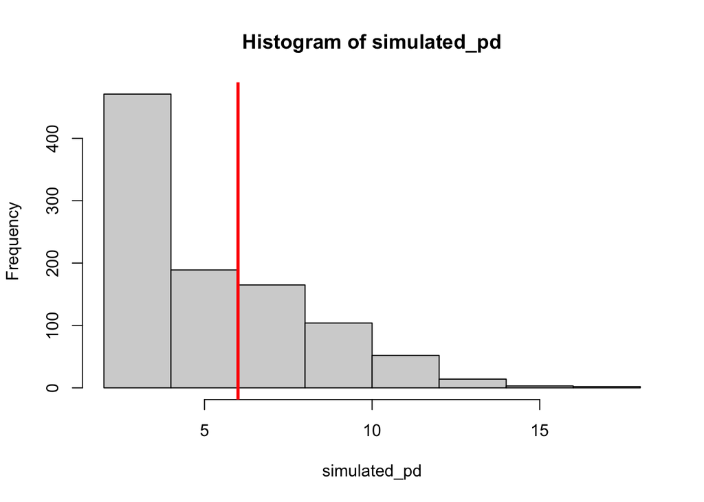

```r
hist(simulated_pd)
abline(v = observed_pd, lw = 3, col = 'red')
```

3. (2 points) How do you conclude? Is this one game sufficient evidence that Bacchus is the superior Ping Pong Player?

## Problem 2: Quality or Quantity? (6pts total)

Marcio Ranchello (fictional) is a prolific architect who has won many accolades. For example, in the ranking of “Best 10 designs of 2023”, 4 of the 10 designs are from Marcio Ranchello. The authors of the ranking report suggest that this is evidence of his greatness. However, you notice that among the 150 buildings considered in the rankings, 30 of them were designed by Marcio. Indeed, Marcio leads a big architecture firm that has been extremely active in designing new buildings.

What do you think? Is the ranking evidence of the quality of his work, or a consequence of the quantity of his designs?

> I feel that the ranking IS evidence of the quality of his work, because so many architects exist that have gotten no recognition for their building designs, and I think that buildings must possess a certain quality in order to receive any accolades.

Take the null hypothesis to be that any of the 150 considered buildings could be included in the top 10 with equal likelihood. How likely under this model would we see 4 (or more) of Ranchello’s buildings in the top 10? What do you conclude?

```r
generate_data = function(alt_buildings, ranchello_buildings, building_spots) {
  all_buildings <- c(rep(0, alt_buildings), rep(1, ranchello_buildings))
  top_ten_buildings <- sample(all_buildings, size = building_spots, replace = FALSE)
  return(sum(top_ten_buildings))
}

NMC = 1e3
simulated_ranchello_count = rep(0, NMC)

for(i in 1:NMC) {
  simulated_ranchello_count[i] = generate_data(120, 30, 10)
}
```

Proceed by treating this as a formal hypothesis test. Define the null and alternative hypotheses, define your test statistic, produce a distribution of simulated test statistics from the null model and finish by calculating a p-value and providing your own interpretation.

> Null hypothesis: Any of the 150 considered buildings could be included in the top 10 with equal likelihood (10/150 or 1/15)

> Alternate: There is not an equal likelihood of each building making it onto the top 10 - specifically, Ranchello buildings are more likely than non-Ranchello buildings

> Test statistic: 4

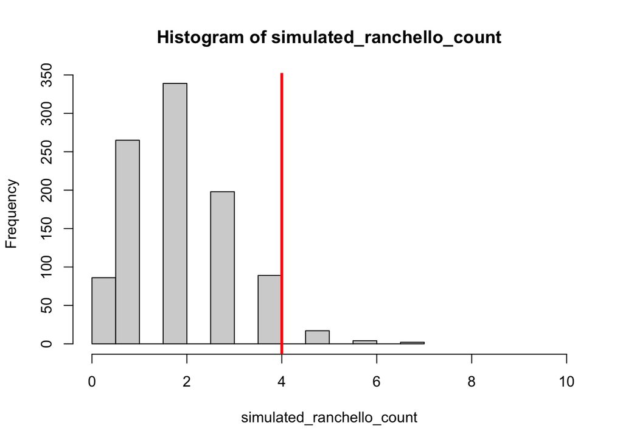

```r
hist(simulated_ranchello_count, xlim = c(min(simulated_ranchello_count), 10))
abline(v = 4, lw = 3, col = 'red')
```

```r
observed_ranchello_count = 4
p_val = sum(simulated_ranchello_count >= observed_ranchello_count)/NMC
p_val
```

```
## [1] 0.112
```

## Problem 3: Permutation testing (8pts)

Below are data arising from a (fictionalized) data source: the number of defects per day on an assembly line before and after installation of a new torque converter (this is a totally fictional “part” of an assembly line–just treat these as “control” and “treatment” groups, respectively).

```r
before = c(4,5,6,3,6,3,4,5,5,3,4,6,4,6,3,4,2,2,0,7,5,8,4,5,1,4,4,8,2,3)
after  = c(3,2,4,3,7,5,5,2,2,4,5,2,2,6,1,5,6,3,2,3,7,3,4,5,4,2,2,6,7,8)
```

1. (4 points) Use a permutation test to assess the claim that installation of the new part changed the prevalence of defects. That is, test the null hypothesis that the distribution of defects is the same before and after installation of the new part. Produce a p-value and interpret the results of your test in context.

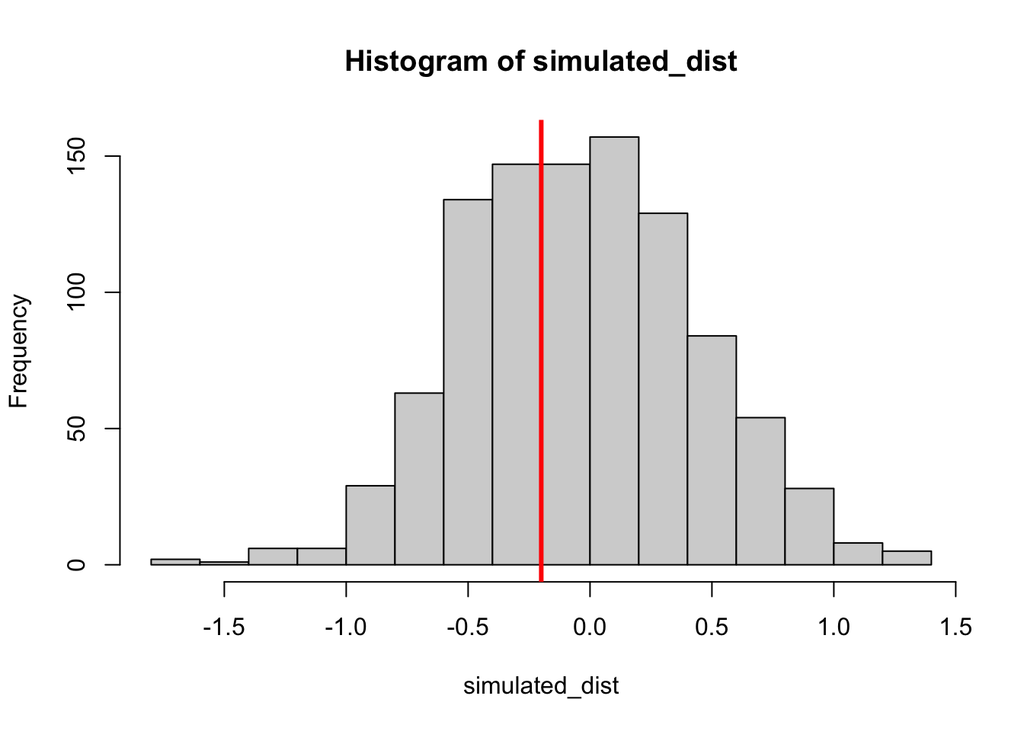

```r
permute_and_compute = function(before_data, after_data) {
  pooled_data = c(before_data, after_data)
  n_before = length(before_data)
  n_after = length(after_data)
  n_total = n_before + n_after

  shuffled_data = sample(pooled_data, size = n_total, replace = FALSE)

  shuffled_before <- shuffled_data[1:n_before]
  shuffled_after <- shuffled_data[(n_before + 1):n_total]

  return(mean(shuffled_after) - mean(shuffled_before))
} # function from L04_testing.html

NMC = 1e3
simulated_dist = rep(0, NMC)

for(i in 1:NMC) {
  simulated_dist[i] = permute_and_compute(before, after)
}

hist(simulated_dist)
abline(v = mean(after) - mean(before), lw = 3, col = 'red')
```

```r
observed_dist = mean(after) - mean(before)
p_val = sum(abs(simulated_dist) >= abs(observed_dist))/NMC
p_val
```

```
## [1] 0.745
```

> The goal of a permutation test is to test a null hypothesis without having to make assumptions on the type of distribution the data follows (i.e. non-parametric). It works by assuming that the two groups being tested came from the same distribution and generates copies of what the data could have looked like if the null were true. The function above repeatedly and randomly reshuffles the data (since any observations are equally likely to be seen in either group under the null), assigns different values to the two groups, and compares means/compares our observed statistic versus our simulated statistic. This allows us to determine if there is strong evidence that our observed statistic is outside of the norm for our distribution.

## Problem 4: Memes (8pts)

The following question comes from Karl Rohe, who developed the very first version of this class. This question has been reproduced in nearly the exact original (very amusing) wording.

> **Memes, part 1** (Please forgive me. I drank too much coffee before writing this question.)

> In class thus far, there have been 416 comments posted in the bbcollaborate chat during class. An expert panel has judged 47 of these comments to be memes. The big-bad-deans say that they are concerned “if there is evidence that more than 10% of comments are memes.” So, this looks like bad news, 47/416>10%.

> Karl pleads with the deans: “Please, oh please, you big-bad-deans… Memeing is totally random.” (I don’t actually know what this notion of “random” means, but please just run with it for this question.) Then, along comes you, a trusty and dedicated 340 student. You say that “because we have only observed 416 comments, we don’t really know what the ‘true proportion’ of memes.”

> 4a: What would be a good distribution for the number of memes?

> Binomial normal

> 4b: Using your distribution from 4a, test the null hypothesis that the ‘true proportion’ is actually 10%. It’s all up to you now… report the p-value.

```r
NMC = 1e3
successes = c()

for(i in 1:NMC) {
  successes = append(successes, sum(rbinom(1, 416, 0.1)) >= 47)
}

p_val = sum(successes)/NMC
p_val
```

```
## [1] 0.199
```

Hints:

- For 4a, there should be a (hopefully) fairly intuitive choice of random variable that makes sense here. Look at your list of random variables and ask yourself which of these makes the most sense.
- For 4b, you can use the built-in function in R to simulate observations according to your null. Remember that you **always simulate *assuming* the null hypothesis**. Make sure your choice of the necessary parameter(s) reflects this assumption.